# The role of irrelevant variables in linear models

This notebook demonstrates overfitting and importance to remove irrelevant variables from a statistical model.

## Artificial data

We will generate artificial data first. The dataset contains 100 independent variables and one dependent variable, all continuous. All the variables follow the normal distribution with zero mean and unit variance. Notice that there is **no relationship between dependent and independent variables**. Consequently, all further findings must be false positives (Type I error).

```r
set.seed(3) # you can change the seed or remove the line to see more runs
d<-data.frame(matrix(rnorm(200*100,0,1),nrow=200))
d$out<-rnorm(200,0,1)
```

## Learn a linear model

Next, we will create a linear regression model. There is no feature selection in this step. Check the number of seemingly relevant independent variables, their number should be around alpha*nvars=5. You may need to generate data multiple times to get an “illustrative” case.

```r
lm.all<-lm(out ~ .,data=d)
lm.all.par<-coefficients(summary(lm.all))
sum(lm.all.par[,"Pr(>|t|)"]<0.05)
```

```
## [1] 4
```

```r
summary(lm.all) # print out the number of significant independent variables
```

```
##
## Call:
## lm(formula = out ~ ., data = d)
##
## Residuals:
##      Min       1Q   Median       3Q      Max
## -1.71750 -0.55166 -0.04587  0.59639  2.31520
##
## Coefficients:
##               Estimate Std. Error t value Pr(>|t|)
## (Intercept) -1.351e-02  1.113e-01  -0.121   0.9036
## X1          -1.787e-01  1.082e-01  -1.652   0.1018
## X2           2.623e-01  1.124e-01   2.334   0.0216 *
## X3           2.221e-01  1.048e-01   2.119   0.0366 *
## X4          -1.251e-01  1.211e-01  -1.033   0.3041
## X5          -1.493e-01  1.080e-01  -1.382   0.1700
## X6          -1.037e-01  1.137e-01  -0.911   0.3643
## X7           1.914e-01  1.195e-01   1.601   0.1125
## X8           1.617e-01  1.205e-01   1.342   0.1827
## X9          -6.043e-02  1.084e-01  -0.558   0.5783
## X10          3.401e-02  1.060e-01   0.321   0.7489
## X11         -1.676e-01  1.172e-01  -1.429   0.1561
## X12          9.697e-02  1.115e-01   0.870   0.3866
## X13          3.607e-02  1.063e-01   0.339   0.7351
## X14          3.719e-02  1.090e-01   0.341   0.7336
## X15         -1.039e-01  1.183e-01  -0.878   0.3823
## X16          2.849e-02  1.249e-01   0.228   0.8201
## X17         -8.893e-02  1.117e-01  -0.796   0.4277
## X18         -7.911e-02  1.165e-01  -0.679   0.4985
## X19          4.472e-03  1.103e-01   0.041   0.9677
## X20         -7.417e-02  1.171e-01  -0.634   0.5278
## X21         -5.447e-02  1.087e-01  -0.501   0.6173
## X22          5.220e-02  1.205e-01   0.433   0.6658
## X23          1.120e-02  1.123e-01   0.100   0.9208
## X24          1.539e-01  1.062e-01   1.450   0.1503
## X25         -3.345e-02  1.146e-01  -0.292   0.7711
## X26         -1.089e-01  1.228e-01  -0.887   0.3773
## X27          7.796e-02  1.127e-01   0.692   0.4909
## X28         -7.585e-02  1.049e-01  -0.723   0.4714
## X29         -3.022e-02  1.212e-01  -0.249   0.8037
```

[output cut: 62 more lines]

```
## X92          7.270e-02  1.153e-01   0.630   0.5299
## X93          8.263e-02  1.073e-01   0.770   0.4429
## X94          1.165e-01  1.117e-01   1.043   0.2996
## X95         -2.243e-01  1.044e-01  -2.148   0.0341 *
## X96          1.262e-01  1.152e-01   1.096   0.2759
## X97          8.587e-02  1.244e-01   0.690   0.4916
## X98         -2.049e-01  1.126e-01  -1.820   0.0718 .
## X99          9.602e-03  1.093e-01   0.088   0.9302
## X100         5.274e-02  1.160e-01   0.455   0.6503
## ---
## Signif. codes:  0 '***' 0.001 '**' 0.01 '*' 0.05 '.' 0.1 ' ' 1
##
## Residual standard error: 1.144 on 99 degrees of freedom
## Multiple R-squared:  0.464,  Adjusted R-squared:  -0.0774
## F-statistic: 0.857 on 100 and 99 DF,  p-value: 0.7786
```

There were 4 independent variables looking significant. On the other hand, both Adjusted R-squared and F-statistic suggest that the full model should not be used and none of its independent variables is truly relevant.

```r
lm.all
```

```
##
## Call:
## lm(formula = out ~ ., data = d)
##
## Coefficients:
## (Intercept)           X1           X2           X3           X4           X5
##  -1.351e-02   -1.787e-01    2.623e-01    2.221e-01   -1.251e-01   -1.493e-01
##          X6           X7           X8           X9          X10          X11
##  -1.037e-01    1.914e-01    1.617e-01   -6.043e-02    3.401e-02   -1.676e-01
##         X12          X13          X14          X15          X16          X17
##   9.697e-02    3.607e-02    3.719e-02   -1.039e-01    2.849e-02   -8.893e-02
##         X18          X19          X20          X21          X22          X23
##  -7.911e-02    4.472e-03   -7.417e-02   -5.447e-02    5.220e-02    1.120e-02
##         X24          X25          X26          X27          X28          X29
##   1.539e-01   -3.345e-02   -1.089e-01    7.796e-02   -7.585e-02   -3.022e-02
##         X30          X31          X32          X33          X34          X35
##  -7.516e-02    1.348e-01   -1.215e-01    1.274e-01   -1.031e-02   -1.118e-01
##         X36          X37          X38          X39          X40          X41
##   6.059e-03    6.237e-02   -1.013e-01    3.014e-02   -7.317e-03    9.551e-02
##         X42          X43          X44          X45          X46          X47
##   3.429e-02   -3.275e-02   -2.283e-02    6.326e-02   -8.991e-02   -1.291e-01
##         X48          X49          X50          X51          X52          X53
##  -4.107e-02   -4.745e-02    2.556e-02    1.105e-01   -1.401e-01    1.219e-01
##         X54          X55          X56          X57          X58          X59
##  -3.604e-02    1.390e-01    8.914e-02    1.874e-01    1.133e-01   -7.545e-02
##         X60          X61          X62          X63          X64          X65
##   4.617e-02   -1.438e-01   -5.427e-02   -8.474e-02    7.870e-02   -5.987e-05
##         X66          X67          X68          X69          X70          X71
##  -2.079e-01    5.217e-02   -1.035e-01    8.384e-02    7.474e-02    4.206e-02
##         X72          X73          X74          X75          X76          X77
##  -1.247e-01    1.530e-01   -8.651e-02   -1.015e-01    1.989e-01   -8.960e-02
##         X78          X79          X80          X81          X82          X83
##  -2.961e-02    3.957e-02    5.116e-02    1.629e-01    6.212e-02   -1.704e-01
##         X84          X85          X86          X87          X88          X89
##  -2.316e-01    1.029e-02    4.341e-02   -5.847e-02    4.877e-02   -8.241e-03
##         X90          X91          X92          X93          X94          X95
##  -1.692e-01    1.923e-02    7.270e-02    8.263e-02    1.165e-01   -2.243e-01
##         X96          X97          X98          X99         X100
##   1.262e-01    8.587e-02   -2.049e-01    9.602e-03    5.274e-02
```

```r
summary(lm.all)
```

```
##
## Call:
## lm(formula = out ~ ., data = d)
##
## Residuals:
##      Min       1Q   Median       3Q      Max
## -1.71750 -0.55166 -0.04587  0.59639  2.31520
##
## Coefficients:
##               Estimate Std. Error t value Pr(>|t|)
## (Intercept) -1.351e-02  1.113e-01  -0.121   0.9036
## X1          -1.787e-01  1.082e-01  -1.652   0.1018
## X2           2.623e-01  1.124e-01   2.334   0.0216 *
## X3           2.221e-01  1.048e-01   2.119   0.0366 *
## X4          -1.251e-01  1.211e-01  -1.033   0.3041
## X5          -1.493e-01  1.080e-01  -1.382   0.1700
## X6          -1.037e-01  1.137e-01  -0.911   0.3643
## X7           1.914e-01  1.195e-01   1.601   0.1125
## X8           1.617e-01  1.205e-01   1.342   0.1827
## X9          -6.043e-02  1.084e-01  -0.558   0.5783
## X10          3.401e-02  1.060e-01   0.321   0.7489
## X11         -1.676e-01  1.172e-01  -1.429   0.1561
## X12          9.697e-02  1.115e-01   0.870   0.3866
## X13          3.607e-02  1.063e-01   0.339   0.7351
## X14          3.719e-02  1.090e-01   0.341   0.7336
## X15         -1.039e-01  1.183e-01  -0.878   0.3823
## X16          2.849e-02  1.249e-01   0.228   0.8201
## X17         -8.893e-02  1.117e-01  -0.796   0.4277
## X18         -7.911e-02  1.165e-01  -0.679   0.4985
## X19          4.472e-03  1.103e-01   0.041   0.9677
## X20         -7.417e-02  1.171e-01  -0.634   0.5278
## X21         -5.447e-02  1.087e-01  -0.501   0.6173
## X22          5.220e-02  1.205e-01   0.433   0.6658
## X23          1.120e-02  1.123e-01   0.100   0.9208
## X24          1.539e-01  1.062e-01   1.450   0.1503
## X25         -3.345e-02  1.146e-01  -0.292   0.7711
## X26         -1.089e-01  1.228e-01  -0.887   0.3773
## X27          7.796e-02  1.127e-01   0.692   0.4909
## X28         -7.585e-02  1.049e-01  -0.723   0.4714
## X29         -3.022e-02  1.212e-01  -0.249   0.8037
```

[output cut: 62 more lines]

```
## X92          7.270e-02  1.153e-01   0.630   0.5299
## X93          8.263e-02  1.073e-01   0.770   0.4429
## X94          1.165e-01  1.117e-01   1.043   0.2996
## X95         -2.243e-01  1.044e-01  -2.148   0.0341 *
## X96          1.262e-01  1.152e-01   1.096   0.2759
## X97          8.587e-02  1.244e-01   0.690   0.4916
## X98         -2.049e-01  1.126e-01  -1.820   0.0718 .
## X99          9.602e-03  1.093e-01   0.088   0.9302
## X100         5.274e-02  1.160e-01   0.455   0.6503
## ---
## Signif. codes:  0 '***' 0.001 '**' 0.01 '*' 0.05 '.' 0.1 ' ' 1
##
## Residual standard error: 1.144 on 99 degrees of freedom
## Multiple R-squared:  0.464,  Adjusted R-squared:  -0.0774
## F-statistic: 0.857 on 100 and 99 DF,  p-value: 0.7786
```

```r
coefficients(summary(lm.all))
```

```
##                  Estimate Std. Error       t value   Pr(>|t|)
## (Intercept) -0.0135073810 0.11129541 -0.1213651243 0.90364784
## X1          -0.1787438486 0.10823005 -1.6515178067 0.10180152
## X2           0.2623492946 0.11239353  2.3342029059 0.02160576
## X3           0.2221132096 0.10484272  2.1185372549 0.03663271
## X4          -0.1251456094 0.12113178 -1.0331360391 0.30405746
## X5          -0.1492778641 0.10799332 -1.3822879800 0.16999395
## X6          -0.1036796614 0.11374854 -0.9114812145 0.36425599
## X7           0.1914266120 0.11954188  1.6013350875 0.11248898
## X8           0.1617202363 0.12052319  1.3418184665 0.18272442
## X9          -0.0604306998 0.10836352 -0.5576664614 0.57833099
## X10          0.0340080659 0.10595456  0.3209683934 0.74891092
## X11         -0.1675592828 0.11724163 -1.4291790838 0.15610064
## X12          0.0969663951 0.11150774  0.8695933832 0.38662613
## X13          0.0360650679 0.10627102  0.3393687835 0.73505079
## X14          0.0371890302 0.10896663  0.3412882609 0.73360988
## X15         -0.1038593904 0.11834824 -0.8775744257 0.38229944
## X16          0.0284926172 0.12493982  0.2280507232 0.82007716
## X17         -0.0889316327 0.11167227 -0.7963627503 0.42772678
## X18         -0.0791079515 0.11645923 -0.6792759399 0.49854812
## X19          0.0044716731 0.11026502  0.0405538678 0.96773323
## X20         -0.0741678213 0.11706638 -0.6335535683 0.52783320
## X21         -0.0544667150 0.10867237 -0.5012011176 0.61734222
## X22          0.0522003430 0.12049553  0.4332139270 0.66580178
## X23          0.0112009719 0.11229962  0.0997418485 0.92075097
## X24          0.1538983317 0.10616093  1.4496701581 0.15031108
## X25         -0.0334484249 0.11462794 -0.2917999212 0.77105018
## X26         -0.1088694037 0.12276940 -0.8867796480 0.37734670
## X27          0.0779614388 0.11273852  0.6915244343 0.49085455
## X28         -0.0758501279 0.10490379 -0.7230447174 0.47135720
## X29         -0.0302153246 0.12120512 -0.2492908251 0.80365231
## X30         -0.0751646422 0.13263579 -0.5666995472 0.57220091
## X31          0.1348343806 0.11526713  1.1697557050 0.24490778
## X32         -0.1214643228 0.11381731 -1.0671867531 0.28848303
## X33          0.1274423200 0.11046909  1.1536469052 0.25142251
## X34         -0.0103104028 0.11214676 -0.0919366986 0.92693411
## X35         -0.1118290623 0.11121378 -1.0055323884 0.31709196
## X36          0.0060585994 0.11403820  0.0531278052 0.95773714
## X37          0.0623740888 0.11743359  0.5311435183 0.59650898
## X38         -0.1013208686 0.11879024 -0.8529393029 0.39575184
```

[output cut: 47 more lines]

```
## X86          0.0434125422 0.11516815  0.3769492099 0.70701812
## X87         -0.0584748648 0.10571941 -0.5531138054 0.58143237
## X88          0.0487688873 0.12039629  0.4050696718 0.68630026
## X89         -0.0082411308 0.10437033 -0.0789604754 0.93722344
## X90         -0.1691874499 0.13655529 -1.2389666790 0.21828725
## X91          0.0192344881 0.10469598  0.1837175435 0.85461081
## X92          0.0726992215 0.11533444  0.6303340428 0.52992836
## X93          0.0826348603 0.10725634  0.7704426654 0.44287205
## X94          0.1164907769 0.11171135  1.0427837155 0.29958822
## X95         -0.2242529296 0.10439138 -2.1481940038 0.03413804
## X96          0.1261763221 0.11516887  1.0955766673 0.27592217
## X97          0.0858737689 0.12439850  0.6903119282 0.49161325
## X98         -0.2048700165 0.11257977 -1.8197764891 0.07181504
## X99          0.0096020990 0.10929473  0.0878550973 0.93016931
## X100         0.0527384008 0.11599524  0.4546600335 0.65034922
```

```r
lm.all.par[,"Pr(>|t|)"]
```

```
## (Intercept)          X1          X2          X3          X4          X5
##  0.90364784  0.10180152  0.02160576  0.03663271  0.30405746  0.16999395
##          X6          X7          X8          X9         X10         X11
##  0.36425599  0.11248898  0.18272442  0.57833099  0.74891092  0.15610064
##         X12         X13         X14         X15         X16         X17
##  0.38662613  0.73505079  0.73360988  0.38229944  0.82007716  0.42772678
##         X18         X19         X20         X21         X22         X23
##  0.49854812  0.96773323  0.52783320  0.61734222  0.66580178  0.92075097
##         X24         X25         X26         X27         X28         X29
##  0.15031108  0.77105018  0.37734670  0.49085455  0.47135720  0.80365231
##         X30         X31         X32         X33         X34         X35
##  0.57220091  0.24490778  0.28848303  0.25142251  0.92693411  0.31709196
##         X36         X37         X38         X39         X40         X41
##  0.95773714  0.59650898  0.39575184  0.78587276  0.94477806  0.41494524
##         X42         X43         X44         X45         X46         X47
##  0.75733124  0.75599557  0.83478477  0.60310149  0.41579489  0.21067671
##         X48         X49         X50         X51         X52         X53
##  0.75051519  0.68312308  0.82046920  0.34543073  0.15154556  0.32121364
##         X54         X55         X56         X57         X58         X59
##  0.76082595  0.27214442  0.40268151  0.10108052  0.31461848  0.50690868
##         X60         X61         X62         X63         X64         X65
##  0.68147019  0.23573200  0.62344571  0.42567470  0.43544175  0.99956790
##         X66         X67         X68         X69         X70         X71
##  0.06182397  0.68451545  0.32891787  0.42550219  0.48141576  0.71404847
##         X72         X73         X74         X75         X76         X77
##  0.31741739  0.21452946  0.49472687  0.38640885  0.07296052  0.42741689
##         X78         X79         X80         X81         X82         X83
##  0.78354140  0.72342250  0.66344207  0.14755560  0.60646050  0.09801452
##         X84         X85         X86         X87         X88         X89
##  0.02576692  0.92485578  0.70701812  0.58143237  0.68630026  0.93722344
##         X90         X91         X92         X93         X94         X95
##  0.21828725  0.85461081  0.52992836  0.44287205  0.29958822  0.03413804
##         X96         X97         X98         X99        X100
##  0.27592217  0.49161325  0.07181504  0.93016931  0.65034922
```

```r
lm.all.par[,"Pr(>|t|)"]<0.05
```

```
## (Intercept)          X1          X2          X3          X4          X5
##       FALSE       FALSE        TRUE        TRUE       FALSE       FALSE
##          X6          X7          X8          X9         X10         X11
##       FALSE       FALSE       FALSE       FALSE       FALSE       FALSE
##         X12         X13         X14         X15         X16         X17
##       FALSE       FALSE       FALSE       FALSE       FALSE       FALSE
##         X18         X19         X20         X21         X22         X23
##       FALSE       FALSE       FALSE       FALSE       FALSE       FALSE
##         X24         X25         X26         X27         X28         X29
##       FALSE       FALSE       FALSE       FALSE       FALSE       FALSE
##         X30         X31         X32         X33         X34         X35
##       FALSE       FALSE       FALSE       FALSE       FALSE       FALSE
##         X36         X37         X38         X39         X40         X41
##       FALSE       FALSE       FALSE       FALSE       FALSE       FALSE
##         X42         X43         X44         X45         X46         X47
##       FALSE       FALSE       FALSE       FALSE       FALSE       FALSE
##         X48         X49         X50         X51         X52         X53
##       FALSE       FALSE       FALSE       FALSE       FALSE       FALSE
##         X54         X55         X56         X57         X58         X59
##       FALSE       FALSE       FALSE       FALSE       FALSE       FALSE
##         X60         X61         X62         X63         X64         X65
##       FALSE       FALSE       FALSE       FALSE       FALSE       FALSE
##         X66         X67         X68         X69         X70         X71
##       FALSE       FALSE       FALSE       FALSE       FALSE       FALSE
##         X72         X73         X74         X75         X76         X77
##       FALSE       FALSE       FALSE       FALSE       FALSE       FALSE
##         X78         X79         X80         X81         X82         X83
##       FALSE       FALSE       FALSE       FALSE       FALSE       FALSE
##         X84         X85         X86         X87         X88         X89
##        TRUE       FALSE       FALSE       FALSE       FALSE       FALSE
##         X90         X91         X92         X93         X94         X95
##       FALSE       FALSE       FALSE       FALSE       FALSE        TRUE
##         X96         X97         X98         X99        X100
##       FALSE       FALSE       FALSE       FALSE       FALSE
```

```r
sum(lm.all.par[,"Pr(>|t|)"]<0.05)
```

```
## [1] 4
```

```r
rownames(lm.all.par)
```

```
##   [1] "(Intercept)" "X1"          "X2"          "X3"          "X4"
##   [6] "X5"          "X6"          "X7"          "X8"          "X9"
##  [11] "X10"         "X11"         "X12"         "X13"         "X14"
##  [16] "X15"         "X16"         "X17"         "X18"         "X19"
##  [21] "X20"         "X21"         "X22"         "X23"         "X24"
##  [26] "X25"         "X26"         "X27"         "X28"         "X29"
##  [31] "X30"         "X31"         "X32"         "X33"         "X34"
##  [36] "X35"         "X36"         "X37"         "X38"         "X39"
##  [41] "X40"         "X41"         "X42"         "X43"         "X44"
##  [46] "X45"         "X46"         "X47"         "X48"         "X49"
##  [51] "X50"         "X51"         "X52"         "X53"         "X54"
##  [56] "X55"         "X56"         "X57"         "X58"         "X59"
##  [61] "X60"         "X61"         "X62"         "X63"         "X64"
##  [66] "X65"         "X66"         "X67"         "X68"         "X69"
##  [71] "X70"         "X71"         "X72"         "X73"         "X74"
##  [76] "X75"         "X76"         "X77"         "X78"         "X79"
##  [81] "X80"         "X81"         "X82"         "X83"         "X84"
##  [86] "X85"         "X86"         "X87"         "X88"         "X89"
##  [91] "X90"         "X91"         "X92"         "X93"         "X94"
##  [96] "X95"         "X96"         "X97"         "X98"         "X99"
## [101] "X100"
```

## See the best predictor

Let us pick the best predictor/independent variable and visualise its relationship with the dependent variable. Both correlation and visual fit look significant, still, it is a false positive due to **selection bias**. The significance is only the outcome of selection of the best variable out of a large pool of irrelevant variables.

```r
pred<-rownames(lm.all.par)[which(lm.all.par[,"Pr(>|t|)"]==min(lm.all.par[,"Pr(>|t|)"]))] # find the most significant predictor
cor.test(d[[pred]],d$out)
```

```
##
##  Pearson's product-moment correlation
##
## data:  d[[pred]] and d$out
## t = 2.1997, df = 198, p-value = 0.02899
## alternative hypothesis: true correlation is not equal to 0
## 95 percent confidence interval:
##  0.01605274 0.28703994
## sample estimates:
##       cor
## 0.1544498
```

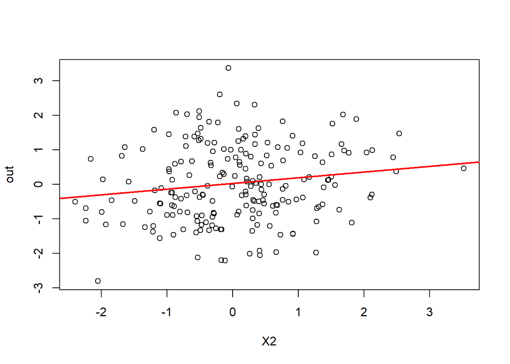

```r
plot(d[[pred]], d$out,xlab=pred,ylab="out") # visualize the relationship between indep and dep variable
abline(lm(as.formula(paste("out~",pred)), d),col="red", lw=2) # visualize the fit
```

The pairwise correlation between the best predictor and the outcome is significant. Note that the correlation coefficient and its p-value may differ from the coefficient and p-value of the given variable observed in the multivariate model above (paired vs multivariate analysis).

## Alternative regression models

There are four alternative linear models to consider: 1. lm.all … the full model, use all 100 independent variables, 2. lm.sel … use only the (seemingly) relevant variables, 3. lm.simple … use only the intercept, 4. lm.zero … always predict zero.

Knowing the origin of data, it is obvious that it holds lm.all<lm.sel<lm.simple<lm.zero when considering model performance on unseen data. The best prediction is to always predict zero. The other linear models will be constructed as follows:

```r
sel.form<-as.formula(paste("out~",paste(rownames(lm.all.par)[lm.all.par[,"Pr(>|t|)"]<0.05],collapse="+")))
lm.sel<- lm(sel.form, data=d) # obviously, it is better to employ lasso or stepwise regression, this is just to illustrate
lm.simple<-lm(out ~ 1,data=d)
lm.zero<-lm(out ~ 0,data=d)
```

```r
sel.form
```

```
## out ~ X2 + X3 + X84 + X95
```

```r
summary(lm.simple)
```

```
##
## Call:
## lm(formula = out ~ 1, data = d)
##
## Residuals:
##     Min      1Q  Median      3Q     Max
## -2.8339 -0.8194 -0.0908  0.8641  3.3342
##
## Coefficients:
##             Estimate Std. Error t value Pr(>|t|)
## (Intercept)  0.03294    0.07790   0.423    0.673
##
## Residual standard error: 1.102 on 199 degrees of freedom
```

```r
summary(lm.zero)
```

```
##
## Call:
## lm(formula = out ~ 0, data = d)
##
## Residuals:
##     Min      1Q  Median      3Q     Max
## -2.8010 -0.7865 -0.0578  0.8970  3.3671
##
## No Coefficients
##
## Residual standard error: 1.099 on 200 degrees of freedom
```

## Compare the alternative models, find the best one

### Large samples, holdout method

Let us suppose the common situation of not knowing the true relationships among variables. The goal is to find the best model, i.e., the model that represents a trade-off between sufficient flexibility and minimal overfitting. In this case, we deal with artificial data and we can easily generate previously unseen test samples. **The holdout method** makes the simplest testing choice here:

```r
d_test<-data.frame(matrix(rnorm(1000*100,0,1),nrow=1000))
d_test$out<-rnorm(1000,0,1)

myRMSE(predict(lm.all,d_test),d_test$out)
```

```
## [1] 1.46135
```

```r
myRMSE(predict(lm.sel,d_test),d_test$out)
```

```
## [1] 1.040769
```

```r
myRMSE(predict(lm.simple,d_test),d_test$out)
```

```
## [1] 0.994938
```

```r
myRMSE(predict(lm.zero,d_test),d_test$out)
```

```
## [1] 0.9946782
```

The zero model shows the smallest root mean squared error. At the same time, the model has the smallest variance in this error (not shown). The holdout method ranks the linear models correctly. The absolute value of calculated RMSE for the zero model matches with the amount of irreducible error (the value of 1 as we deal with the outcome that has zero mean and unit variance).

### Small samples, ANOVA and cross-validation

Often, the sample set is small and new observations cannot be easily reached. Under such circumstances, ANOVA and cross-validation are available to compare the models. Let us start with ANOVA:

```r
anova(lm.zero,lm.simple,lm.sel,lm.all)
```

|  | Res.Df | RSS | Df | Sum of Sq | F | Pr(>F) |
| --- | --- | --- | --- | --- | --- | --- |
| 1 | 200 | 241.7399 | NA | NA | NA | NA |
| 2 | 199 | 241.5229 | 1 | 0.2170007 | 0.1659505 | 0.6846156 |
| 3 | 195 | 224.5144 | 4 | 17.0085789 | 3.2518133 | 0.0149781 |
| 4 | 99 | 129.4546 | 96 | 95.0597110 | 0.7572562 | 0.9138584 |

```r
anova(lm.zero,lm.all)
```

|  | Res.Df | RSS | Df | Sum of Sq | F | Pr(>F) |
| --- | --- | --- | --- | --- | --- | --- |
| 1 | 200 | 241.7399 | NA | NA | NA | NA |
| 2 | 99 | 129.4546 | 101 | 112.2853 | 0.850196 | 0.7909779 |

ANOVA may often recommend lm.sel, which is not correct. The method may suffer from conceptual simplicity of the test (no need for test data, the decision made on train data only). However, ANOVA does not prefer lm.all over lm.zero. In general, it is a legitimate option. Let us employ cross-validation now:

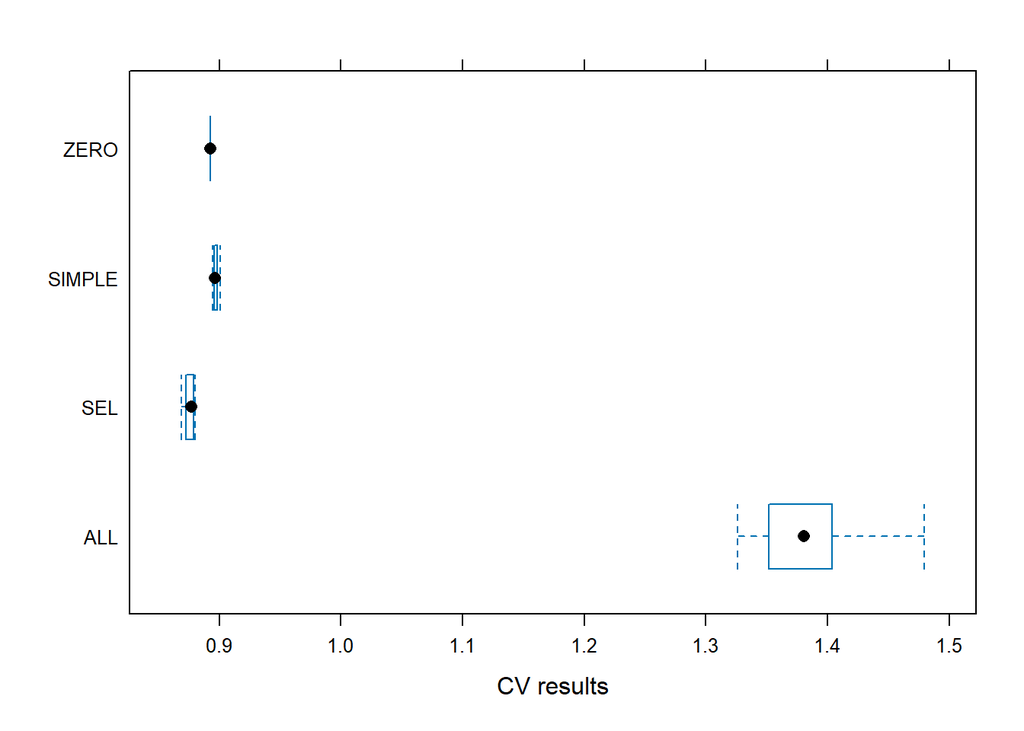

```r
folds <- cvFolds(nrow(d), K = 10, R = 10) # 10 times repeated 10-fold CV
cvFitLmAll <- cvLm(lm.all, cost = rtmspe, folds = folds, trim = 0.1)
cvFitLmSel <- cvLm(lm.sel, cost = rtmspe, folds = folds, trim = 0.1)
cvFitSimple <- cvLm(lm.simple, cost = rtmspe, folds = folds, trim = 0.1)
cvFitZero <- cvLm(lm.zero, cost = rtmspe, folds = folds, trim = 0.1)
cvFits <- cvSelect(ALL = cvFitLmAll, SEL = cvFitLmSel, SIMPLE = cvFitSimple, ZERO=cvFitZero)
bwplot(cvFits) # rmse is the default cost function
```

The recommendation is misleading again, sel is best, full model worst. The problem was methodological in this case, **we cannot do feature selection on all the data**, we must proceed independently in all the folds! We will not implement the correct way of cross-validation here. However, remember that correct CV implementation could be non-trivial when doing learning, data preprocessing and hyperparameter tuning at the same time.

## Summary

Irrelevant features cause overfitting and make our models work worse on unseen data. If having a finite/limited sample set the learning algorithm finds spurious relationships which increases variance and thus error. Removal of irrelevant features is crucial namely when dealing with a large number of them. (Proper) testing on unseen data (hold-out method, cross-validation) can help to detect overfitting and find out the optimal complexity of the model. ANOVA helps to decide the complexity from one run of the model only.

**Further questions and tasks:**

1. Show how the previously learned feature selection methods (p-values, stepwise selection, shrinkage) work in this case. Clearly demonstrate whether they work well/fail and explain why. Play with several different random generator seeds.

```r
lm.step.both <- stepAIC(lm.all, direction="both")
```

```
## Start:  AIC=115
## out ~ X1 + X2 + X3 + X4 + X5 + X6 + X7 + X8 + X9 + X10 + X11 +
##     X12 + X13 + X14 + X15 + X16 + X17 + X18 + X19 + X20 + X21 +
##     X22 + X23 + X24 + X25 + X26 + X27 + X28 + X29 + X30 + X31 +
##     X32 + X33 + X34 + X35 + X36 + X37 + X38 + X39 + X40 + X41 +
##     X42 + X43 + X44 + X45 + X46 + X47 + X48 + X49 + X50 + X51 +
##     X52 + X53 + X54 + X55 + X56 + X57 + X58 + X59 + X60 + X61 +
##     X62 + X63 + X64 + X65 + X66 + X67 + X68 + X69 + X70 + X71 +
##     X72 + X73 + X74 + X75 + X76 + X77 + X78 + X79 + X80 + X81 +
##     X82 + X83 + X84 + X85 + X86 + X87 + X88 + X89 + X90 + X91 +
##     X92 + X93 + X94 + X95 + X96 + X97 + X98 + X99 + X100
##
##        Df Sum of Sq    RSS    AIC
## - X65   1    0.0000 129.46 113.00
## - X19   1    0.0022 129.46 113.01
## - X36   1    0.0037 129.46 113.01
## - X40   1    0.0063 129.46 113.01
## - X89   1    0.0082 129.46 113.02
## - X99   1    0.0101 129.47 113.02
## - X34   1    0.0111 129.47 113.02
## - X85   1    0.0117 129.47 113.02
## - X23   1    0.0130 129.47 113.02
## - X91   1    0.0441 129.50 113.07
## - X44   1    0.0572 129.51 113.09
## - X50   1    0.0677 129.52 113.11
## - X16   1    0.0680 129.52 113.11
## - X29   1    0.0813 129.54 113.13
## - X39   1    0.0970 129.55 113.15
## - X78   1    0.0992 129.55 113.16
## - X25   1    0.1113 129.57 113.17
## - X54   1    0.1218 129.58 113.19
## - X42   1    0.1255 129.58 113.20
## - X43   1    0.1270 129.58 113.20
## - X48   1    0.1329 129.59 113.21
## - X10   1    0.1347 129.59 113.21
## - X13   1    0.1506 129.60 113.23
## - X14   1    0.1523 129.61 113.24
## - X79   1    0.1647 129.62 113.26
## - X71   1    0.1766 129.63 113.28
## - X86   1    0.1858 129.64 113.29
```

[output cut: 8425 more lines]

```
## - X83   1    3.5726 164.81 15.300
## - X53   1    3.7370 164.98 15.499
## - X81   1    3.9148 165.16 15.715
## - X52   1    3.9236 165.16 15.725
## - X76   1    4.1292 165.37 15.974
## - X51   1    4.2117 165.45 16.074
## - X66   1    4.2953 165.54 16.175
## - X57   1    4.5979 165.84 16.540
## - X5    1    4.6030 165.84 16.546
## - X11   1    4.7854 166.03 16.766
## - X90   1    4.8629 166.10 16.859
## - X3    1    7.8481 169.09 20.422
## - X84   1    8.6869 169.93 21.412
## - X95   1   11.3771 172.62 24.553
## - X2    1   13.6145 174.86 27.129
```

```r
lm.step.both
```

```
##
## Call:
## lm(formula = out ~ X1 + X2 + X3 + X5 + X6 + X7 + X8 + X11 + X24 +
##     X35 + X45 + X46 + X51 + X52 + X53 + X55 + X57 + X66 + X74 +
##     X76 + X81 + X83 + X84 + X90 + X95 + X98 + X23, data = d)
##
## Coefficients:
## (Intercept)           X1           X2           X3           X5           X6
##    -0.01037     -0.14230      0.27074      0.20717     -0.16204     -0.09971
##          X7           X8          X11          X24          X35          X45
##     0.13084      0.13988     -0.16883      0.10049     -0.12892      0.10568
##         X46          X51          X52          X53          X55          X57
##    -0.11790      0.15612     -0.13353      0.14508      0.12602      0.15896
##         X66          X74          X76          X81          X83          X84
##    -0.15695     -0.11662      0.15418      0.14705     -0.13321     -0.21688
##         X90          X95          X98          X23
##    -0.18101     -0.24472     -0.12054      0.12968
```

```r
myRMSE(predict(lm.step.both,d_test),d_test$out)
```

```
## [1] 1.294234
```

```r
library(glmnet)
X <- as.matrix(d[, 1:100])
y <- d$out
lasso.cv <- cv.glmnet(X, y, alpha = 1)

X_test <- as.matrix(d_test[, 1:100])
y_test <- d_test$out

pred_lasso <- predict(lasso.cv, s = "lambda.min", newx = X_test)
myRMSE(pred_lasso, y_test)
```

```
## [1] 0.994938
```

#### p-value

- In the lab, we selected variables based on their p-values (p < 0.05).
- However, this approach has two major issues:
  1. Because we test 100 predictors independently at alpha = 0.05, we expect about five false positives by chance, and we cannot tell which ones they are.
  2. Because all predictors are random noise, any variable that appears significant is a false positive.

#### Stepwise selection

- The resulting model has RMSE = 1.29, which is worse than the model based on p-values.
- It selects variables that minimize AIC on the training data, but since all predictors are irrelevant, the selection is random and unstable.

#### Lasso

- LASSO shrinks irrelevant coefficients toward zero, producing a model similar to the zero model, which is optimal in this experiment.
2. Describe step by step the correct way of model comparison procedure through cross-validation that was incorrectly implemented above. You can also implement the procedure, however, the implementation is optional only.
- The previous cross-validation was done incorrectly because the model was trained on the entire dataset before testing. That means we tested the model on the same data it was trained on.
- The correct way how to implement it is to repeat the training and testing process for each fold. In every iteration, use only the training part of the data to train the model, then test it on the remaining fold. Finally, average the performance across all folds to get estimate of how the model really performs.